# 葡萄酒相关成分影响探索性数据分析

[output not shown]

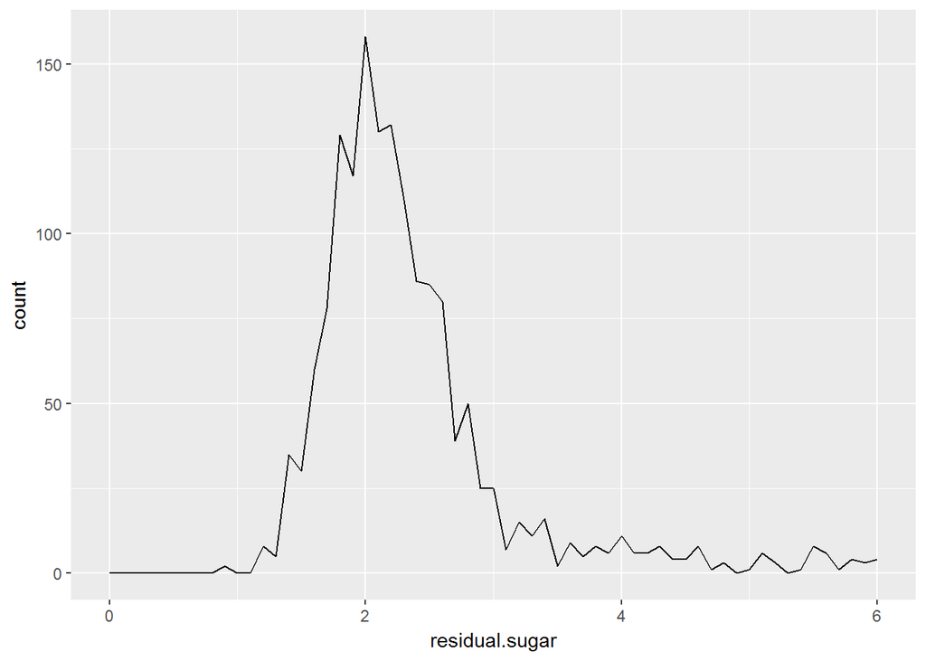

```
##    Min. 1st Qu.  Median    Mean 3rd Qu.    Max.
##   0.900   1.900   2.200   2.539   2.600  15.500
```

上图分析了葡萄酒中残糖的分布情况,数据中存在长尾现象，剔除了长尾信息后，得到的分布为类似正态分布

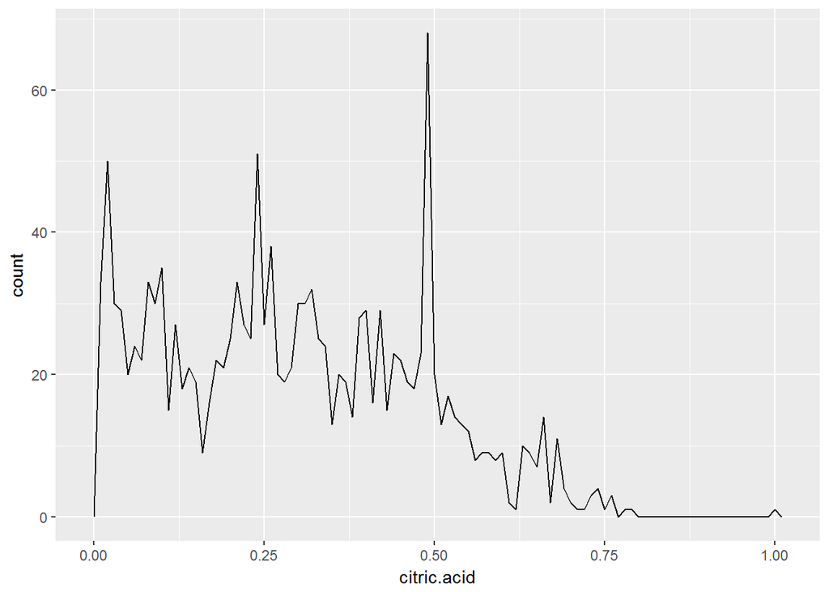

```
##    Min. 1st Qu.  Median    Mean 3rd Qu.    Max.
##   0.000   0.090   0.260   0.271   0.420   1.000
```

上图分析了葡萄酒中柠檬酸的分布情况,明显呈现出了斜分布的情况，在数据中大量存在柠檬酸为0的情况，分析中剔除了为零的数据，在这里明显看出在柠檬酸等于0.5位置出现了大量的分布，并且出现了多峰分布的情况

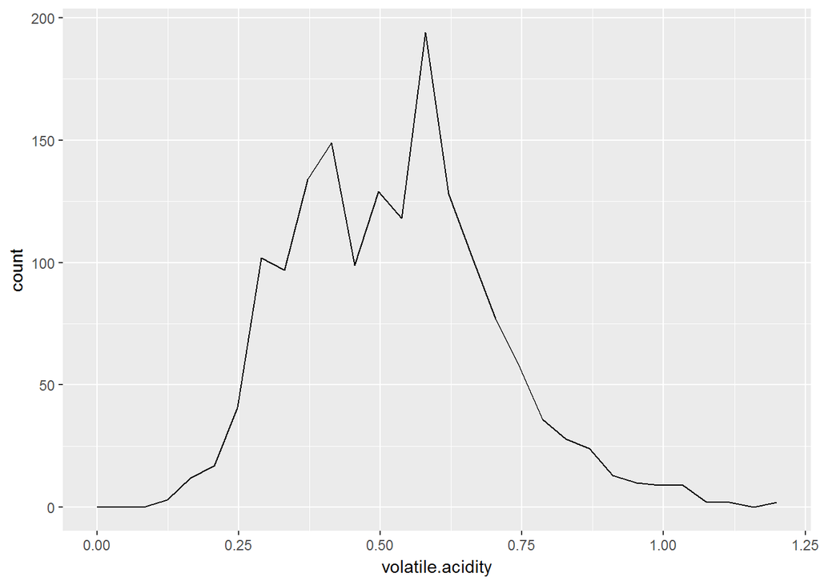

```
##    Min. 1st Qu.  Median    Mean 3rd Qu.    Max.
##  0.1200  0.3900  0.5200  0.5278  0.6400  1.5800
```

上图分析了挥发酸在葡萄酒中的分布情况,删除其中的长尾数据,数据呈现出了类似正态分布的情况

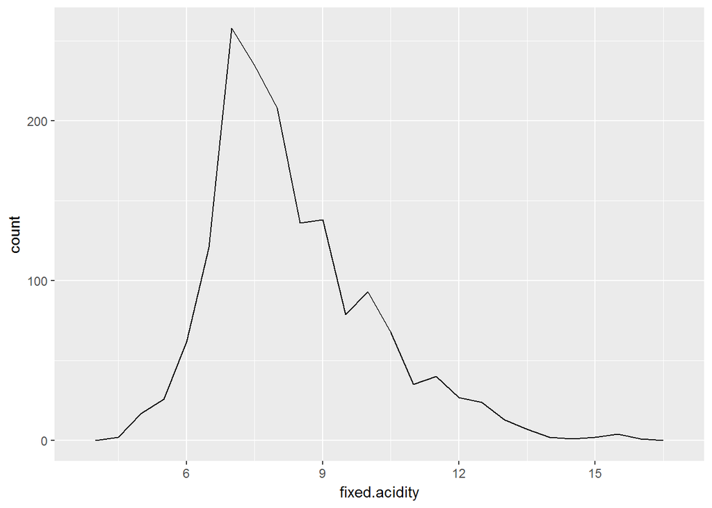

上图分析了非挥发性酸在葡萄酒样本中的分布情况,分布类似正态分布 # 单变量分析 ### 数据集结构如何? 葡萄酒数据集中包含了1599个样本数据，包含了13个变量，非挥发性酸含量、挥发性酸含量、柠檬酸含量、残糖的含量、氯化物的含量、游离二氧化硫含量，二氧化硫含量、密度、PH值、硫酸盐含量、酒精度及打分的情况。 根据上面的分析，我们得出的情况如下

### 数据集中最感兴趣的特征是那些?

最有兴趣的是：葡萄酒评分的分布、酒精度的分布、各类酸的分布、糖类含量的分布。 ### 数据集中哪些其他因素将有助于你分析你有兴趣的因素？ 酸的组成由多种，互相之间有什么影响？数据集中那些分布存在长尾线性，是否异常，存在为0的值吗？为什么，是否所有影响因子都呈现出正态分布的情况。如果不是正态分布，为什么？ ### 你有在数据集中根据已有变量创建新的变量吗？

1. 在分析硫化物的时候，创建了新变量记录游离和非游离二氧化硫的总量和来分析葡萄酒中二氧化硫对评分的影响
2. 在分析酸和PH值之间的关系是，创建了新变量把所有的非挥发性酸、挥发性酸、柠檬酸相加后得出了总酸变量

### 您调查的功能，有任何不寻常的分布？您是否对数据执行任何操作来整理、调整或更改数据的格式？如果是的话，你为什么这样做？

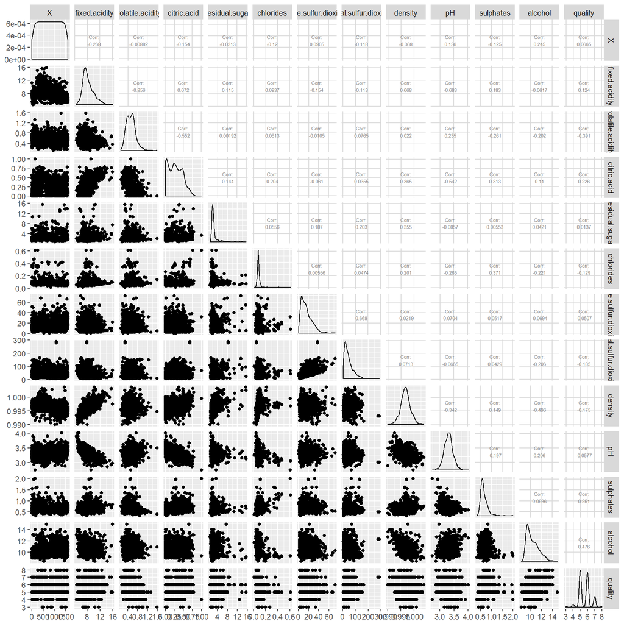

按照葡萄酒的分级类别对酒精度的均值和中位数进行了分析，可以看出随着酒精度数的增加，红酒分级评分变高，但是在评级为5的地方出现了异常，因为这里酒精度数突然下降了

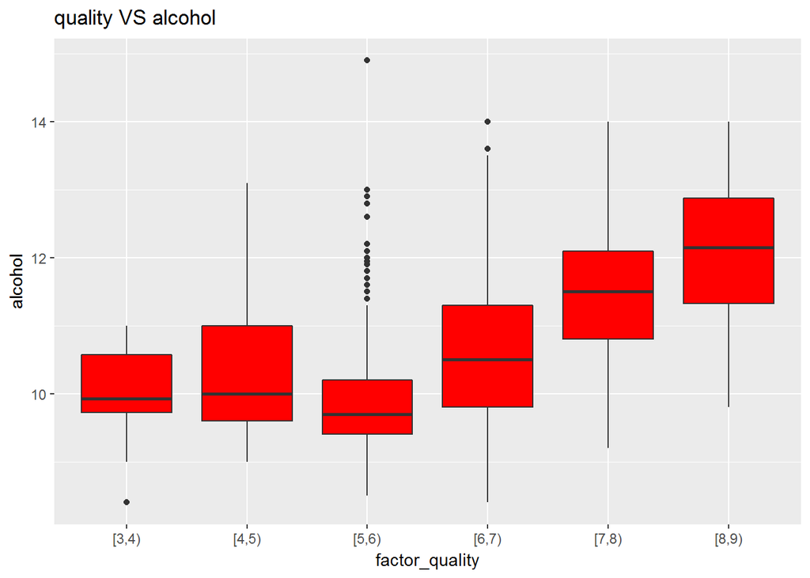

上图分析了葡萄酒评分和酒精度数的关系，其中看出，在质量为5的位置出现了无论中位数，均值，箱体长度都较低，而且出现了较多的异常点。

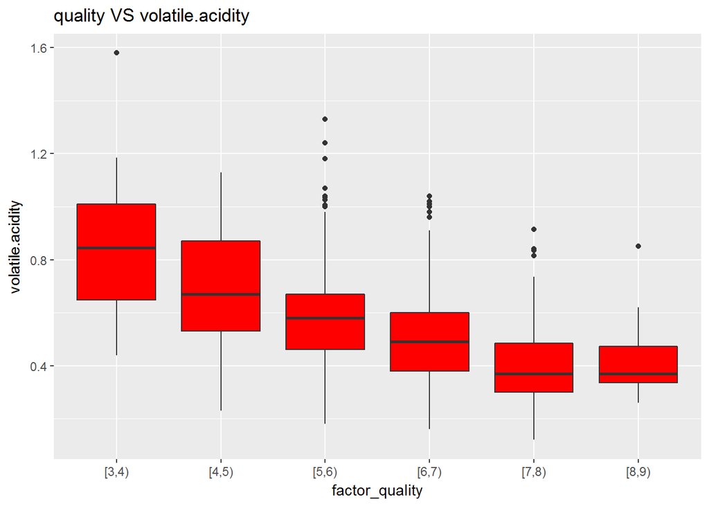

上图分析了葡萄酒评分和挥发性酸的关系图，其中看出，整个箱体的中位数呈现出了逐渐降低的过程过程，表现出明显的线性关系。

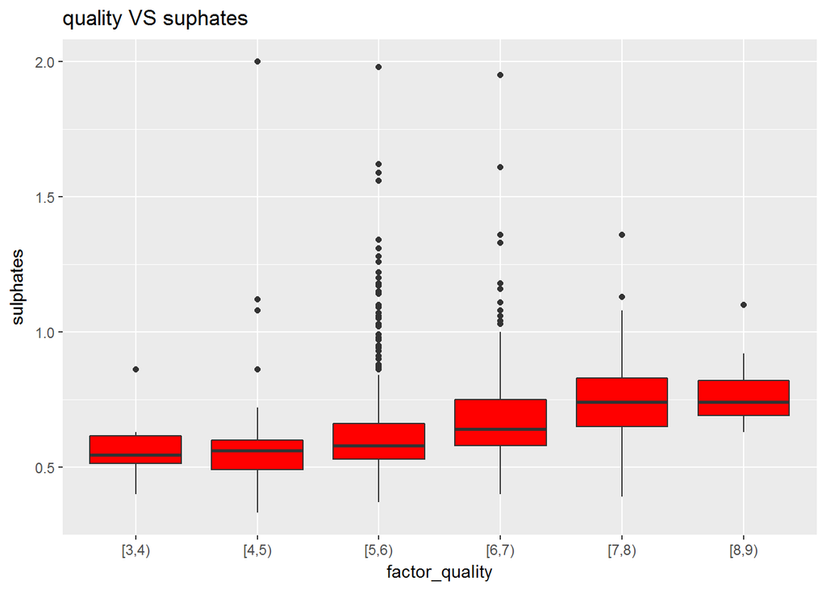

上图分析了葡萄酒评分和硫酸盐含量之间的关系，其中看出程序出了一定的线性关系，但是在评分为5的位置出现了明显的异常点数量

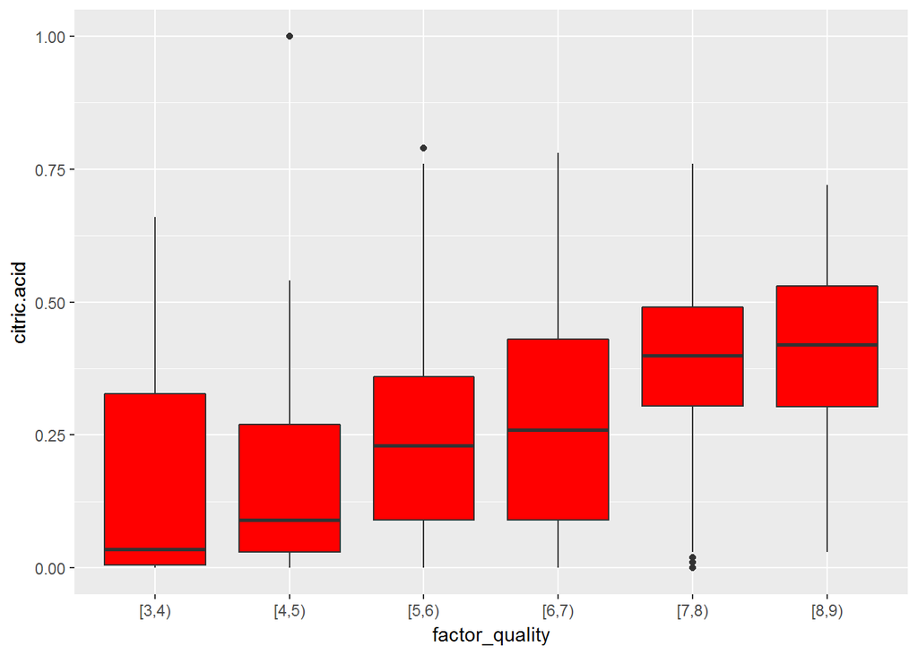

```
## $title
## [1] "quality VS ctric.acid"
##
## attr(,"class")
## [1] "labels"
```

上图分析了葡萄酒评分和柠檬酸盐含量之间的关系，其中看出程序出了一定的线性关系。

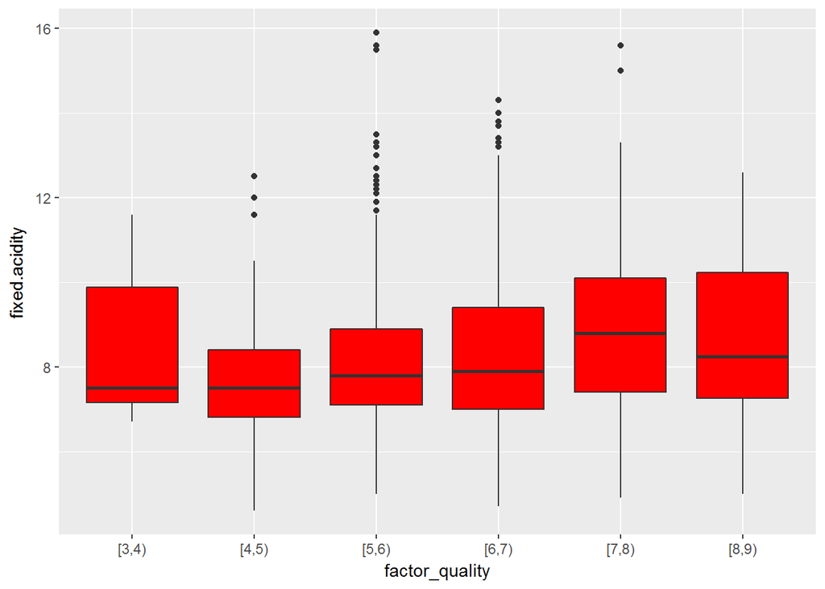

```
## $title
## [1] "quality VS fixed.acidity"
##
## attr(,"class")
## [1] "labels"
```

上图分析了非游离酸和评分之间的关系，在这个关系中，在评分为5的位置上面出现了大量的异常数据点。

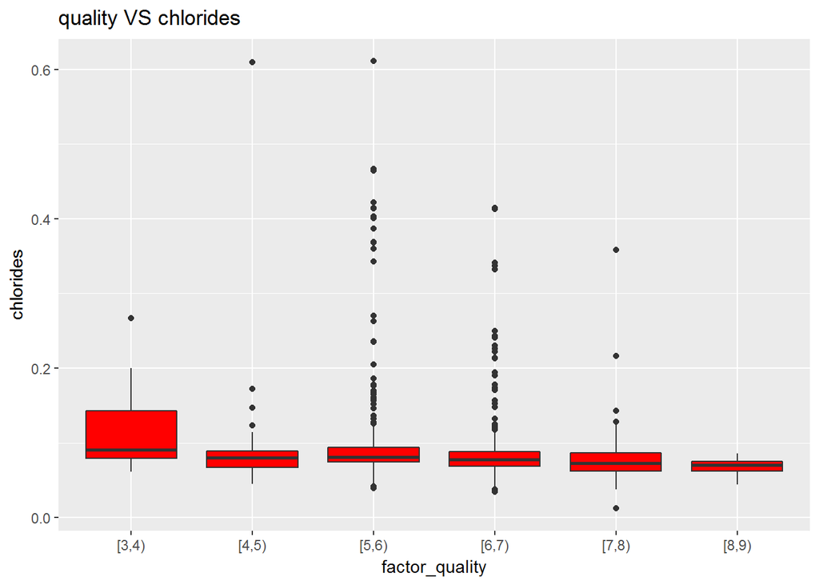

上图中分析了氯化物和质量评分之间的关系，在评分为5,6的位置出现了大量的异常数据

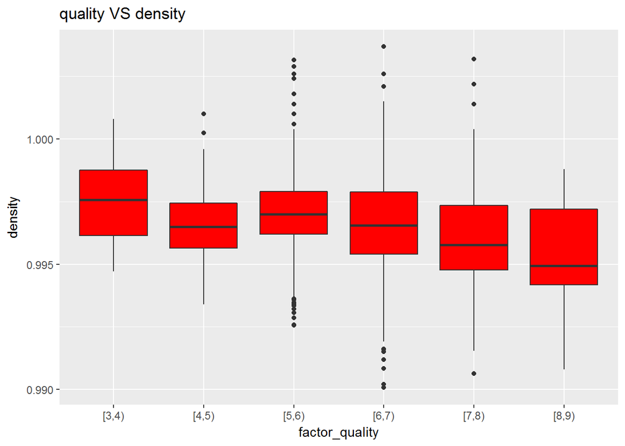

分析密度和葡萄酒评分之间的关系，在这个关系中，在评分等于5,6 的位置出现了大量的异常数据

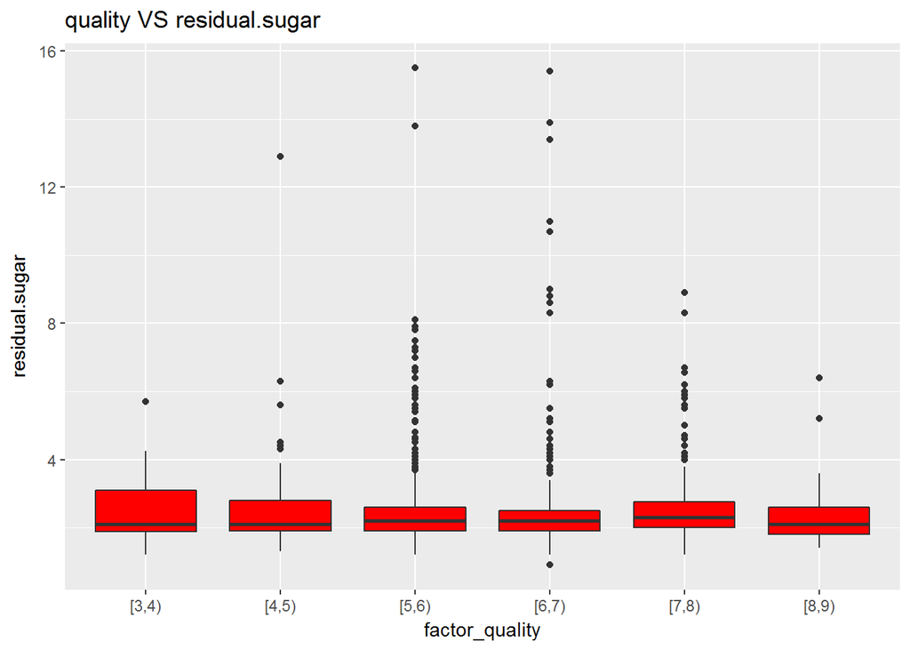

上图中分析了糖含量和葡萄酒质量之间的关系。

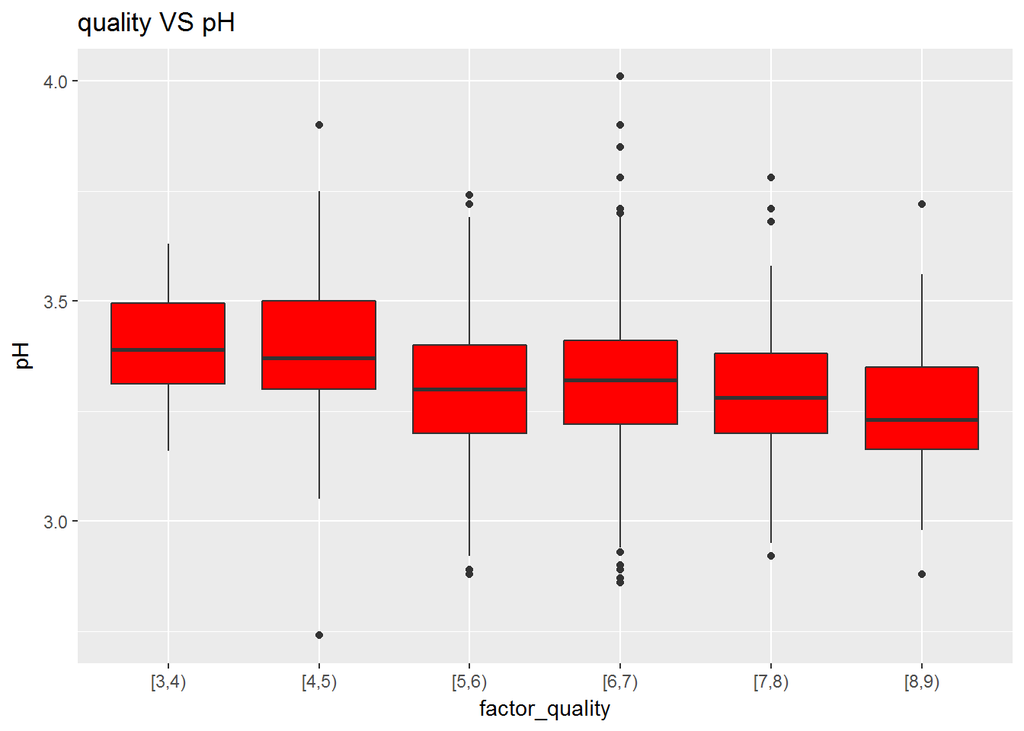

上图分析了pH值和葡萄酒质量之间的关系，这里在评分为5,6的位置出现了大量的异常

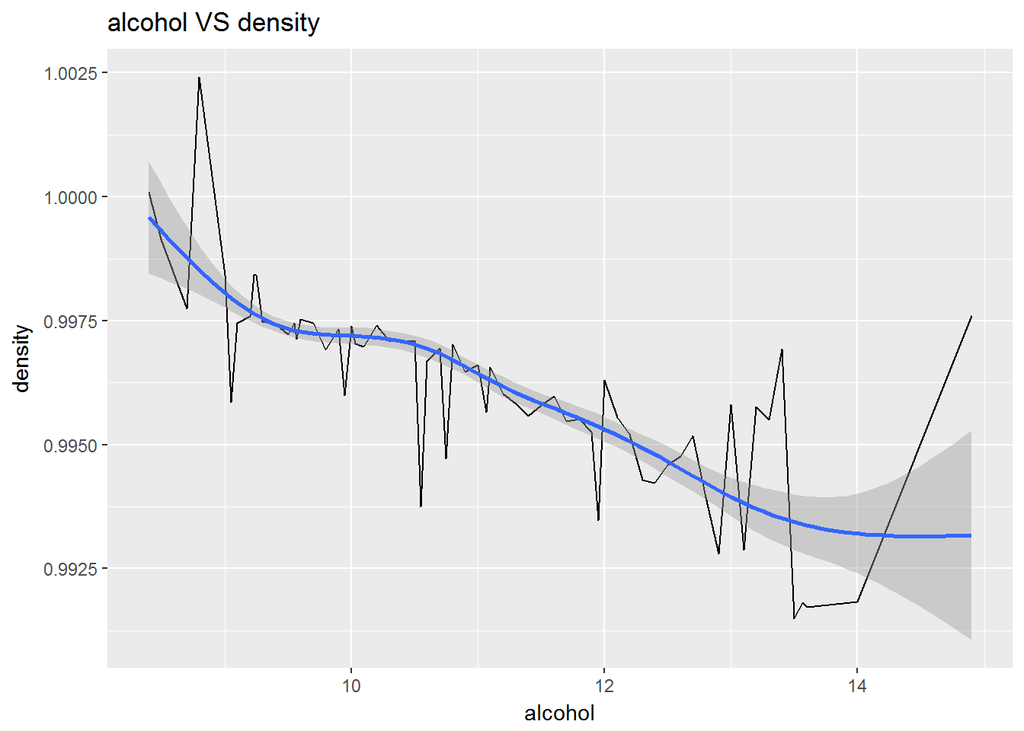

上图分析了酒精度和密度之间的关系

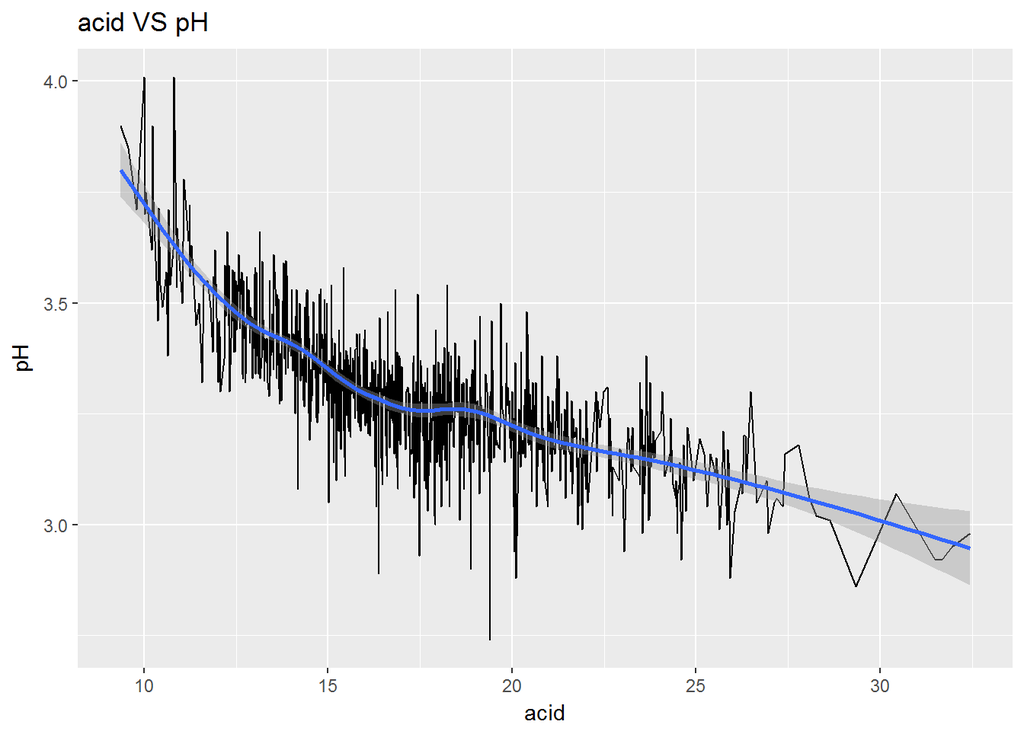

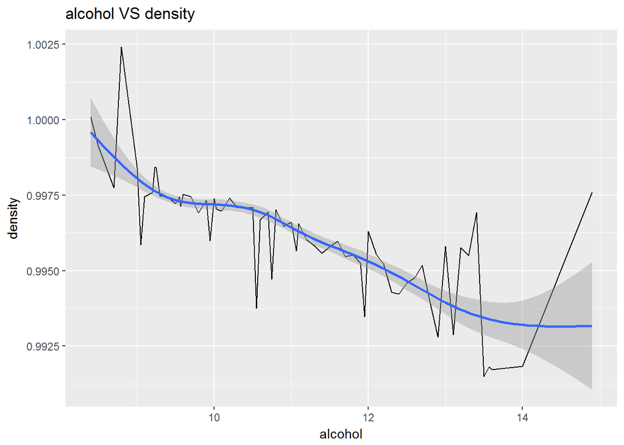

上图分析了酒精度和密度之间的关系，酒精含量高则葡萄酒密度较低，这也符合化学常识。因为葡萄酒大量含量为水，酒精比水密度低。

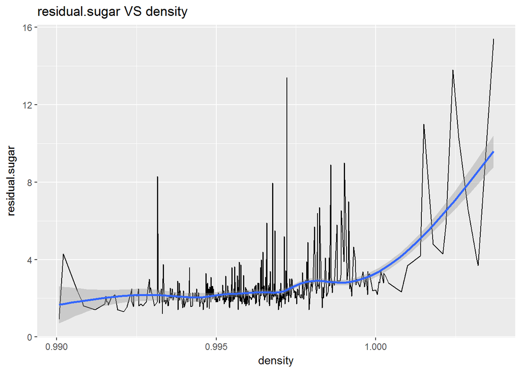

上图分析了密度和含糖量之间的关系，含糖量越高，密度越高，这也符合我们物理常识。

# 二个变量之间的分析

### 谈谈你在这部分调查中观察到的一些关系。如何感兴趣的功能（S）随数据集中的其他功能？

在二元变量分析中，我感兴趣的点主要是关注于葡萄酒的评分和其他变量之间的关系有什么样的联系，为此使用了ggparis分析了所有数据集变量中的两两关系，并且从中分析了其中关联程度较高的变量之间的关系。在这些关系中，很多的变量和葡萄酒评分之间呈现出了明显的线性关系，但是这种线性关系，在评分为5的葡萄酒中存在大量的异常值，即不符合线性回归的情况。

### 你是否观察到其他特征之间的有趣关系（而不是主要特征）？

分析了酒精度和密度，糖度和密度之间的关系，酸度和pH之间的关系，这些都不是主要特征，但是符合我们的化学常识。

### 你发现的最强烈的关系是什么？?

酒精度和葡萄酒评分之间呈现出的相关系数为0.476的相关系数，在这个关系中，我们根据分析，可以推论对葡萄酒评分影响最大的因素为葡萄酒酒精度数，即酒精度数越高，则葡萄酒评分越高。

# 多变量的图形

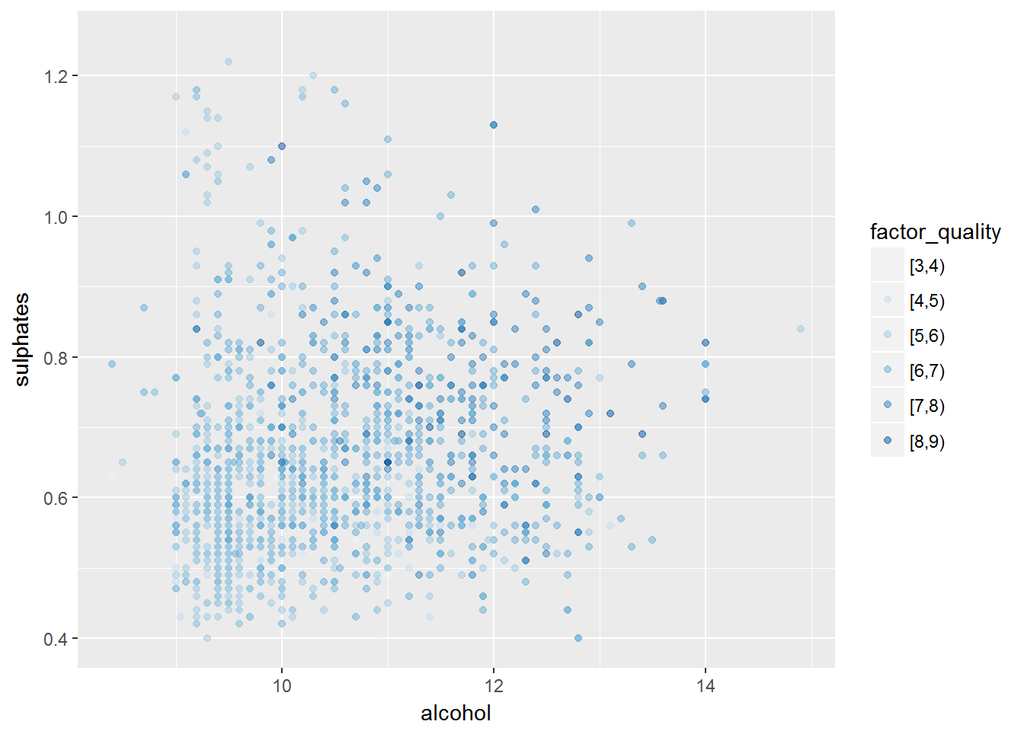

```
## $title
## [1] "alcohol VS sulphates VS quality"
##
## attr(,"class")
## [1] "labels"
```

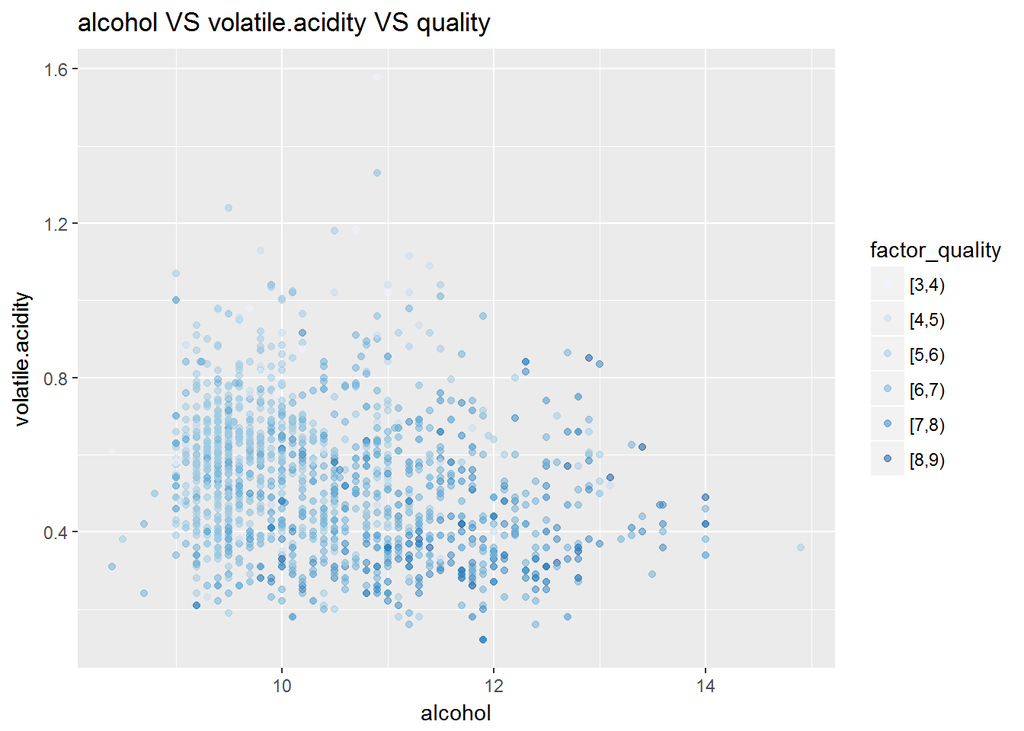

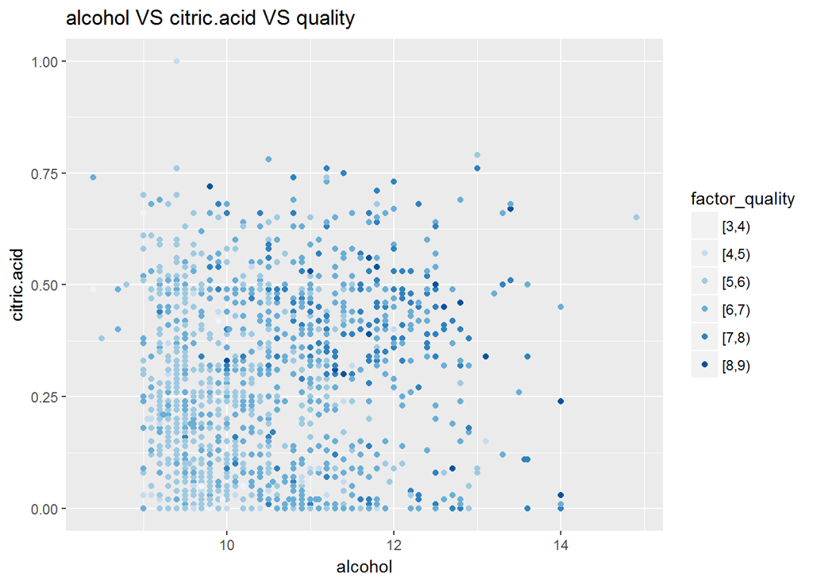

```
##
## Calls:
## m1: lm(formula = I(quality ~ alcohol), data = df)
## m2: lm(formula = quality ~ alcohol + volatile.acidity, data = df)
## m3: lm(formula = quality ~ alcohol + volatile.acidity + sulphates,
##     data = df)
## m4: lm(formula = quality ~ alcohol + volatile.acidity + sulphates +
##     citric.acid, data = df)
##
## ================================================================
##                        m1         m2         m3         m4
## ----------------------------------------------------------------
##   (Intercept)        1.875***   3.095***   2.611***   2.646***
##                     (0.175)    (0.184)    (0.196)    (0.201)
##   alcohol            0.361***   0.314***   0.309***   0.309***
##                     (0.017)    (0.016)    (0.016)    (0.016)
##   volatile.acidity             -1.384***  -1.221***  -1.265***
##                                (0.095)    (0.097)    (0.113)
##   sulphates                                0.679***   0.696***
##                                           (0.101)    (0.103)
##   citric.acid                                        -0.079
##                                                      (0.104)
## ----------------------------------------------------------------
##   R-squared              0.2        0.3        0.3        0.3
##   adj. R-squared         0.2        0.3        0.3        0.3
##   sigma                  0.7        0.7        0.7        0.7
##   F                    468.3      370.4      268.9      201.8
##   p                      0.0        0.0        0.0        0.0
##   Log-likelihood     -1721.1    -1621.8    -1599.4    -1599.1
##   Deviance             805.9      711.8      692.1      691.9
##   AIC                 3448.1     3251.6     3208.8     3210.2
##   BIC                 3464.2     3273.1     3235.7     3242.4
##   N                   1599       1599       1599       1599
## ================================================================
```

# 多变量分析部分

# 反映出的结果

### 图1

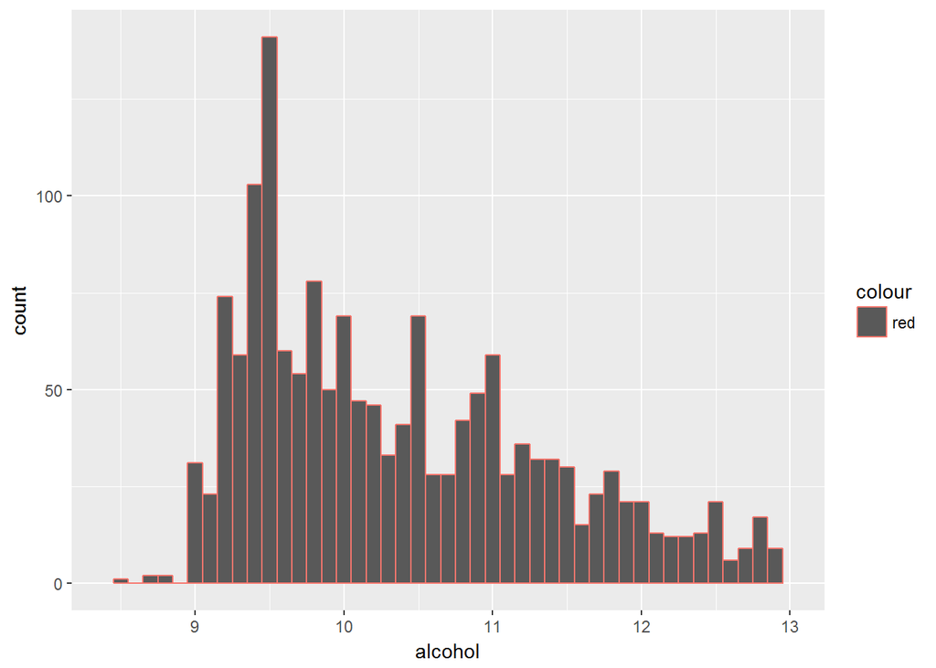

### 图1的描述

从图上我们可以看出，在葡萄酒数据集中，大量酒精最多的度数在9-10度之间，在这个部分我们可以这个图中，葡萄酒的酒精含量中，高度酒数量很少。

### 图2

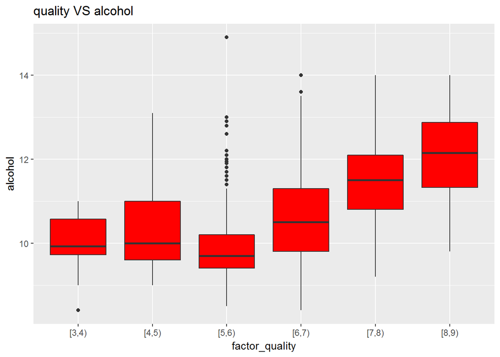

### 图2 的描述

根据对数据集中多对变量的分析，我们看出酒精度数是对葡萄酒品质影响最高的变量，他们两者之间相关系数为0.47,从箱线图中，我们可以看到随着酒精度数的中位数不断的增加，葡萄酒的评分也不断的增大，但是在评分为5的位置出现了大量的异常值，集中在酒精度较高的部分，这里表面酒精度对葡萄酒质量评分具有线性相关的关系，我们后面主要就关注酒精度和评分之间的关系。

### 图3

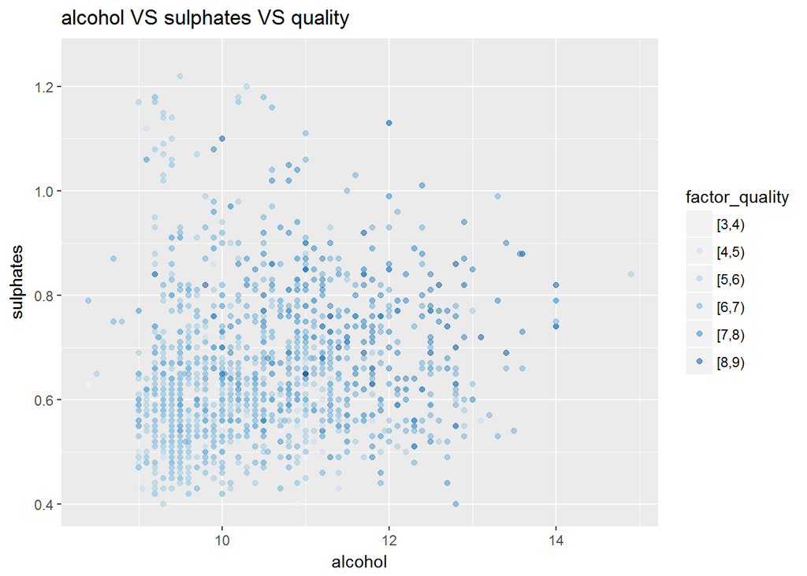

### 图3的描述

因为我们关注的焦点在于葡萄酒中影响品质评分的相关变量，图3我们分析了酒精度和硫化物含量之间的关系，在这里选择硫化物是因为在所有相关系数中，这两个是数量较大并且呈现出正相关系数的变量，所以，我们是否能得出推论，我们购买更高品质的葡萄酒的时候，应该先去选择酒精度高的葡萄酒，然后去选择硫化物含量较高的。 # 反映出的效果

# 在探索过程中遇到的问题

在这个探索过程中，所有变量之间，一些呈现出了正态分布，另外一些则表现出了较多的异常值，这个情况比较让我困惑，对单个变量的分布，使用对数变换后，解决了部分的问题，但是还是有一些呈现出了双峰分布的情况。

在探索过程中，对quality变量的认定过程中，认定的是序列变量，但是在绘图的过程中，程序已知认定为了连续变量，所以我查阅了相关文档，使用cut函数先对quality数据进行分组后，才得到了相关分组信息，绘制了箱线图

对这个项目中，我们从目前具有的数据集进行分析，能否收集到更多变量，更多数量的数据集，研究究竟哪些变量能够进一步影响葡萄酒品质，甚至到葡萄酒价格的因素，是我很有兴趣的问题。

# 参考的文章

影响红酒质量的因素 http://www.wine-world.com/culture/pj/20130821095156901

影响葡萄酒品质的六大因素 http://www.yhj9.com/article-1933.html